Title: Computational Thinking for Governance Analytics, Final Project

By: Alexa Schreier

Date: 6 March 2018

1. Getting the Data The data used for this report was collected and made available by the United States’ National Park Service. The data can be found and accessed at the following site: [(https://irma.nps.gov/Stats/SSRSReports/National%20Reports/Annual%20Visitation%20by%20Park%20Type%20or%20Region%20(1979%20-%20Last%20Calendar%20Year))]

```r
#Import data into RStudio library
library(readxl)
library(cluster)
library(utils)
library(rgdal)
library(jsonlite)
library(tidyverse)
temp = tempfile(fileext = ".xlsx")
dataURL <- "https://github.com/alexaschreier/data/raw/master/data.xlsx"
download.file(dataURL, destfile=temp, mode='wb')
Parkdata = read_excel(temp, sheet =1)
```

2. Exploring the Data The data explored below includes records of all areas owned and managed by the United States’ National Park Service. The data is broken out by region, park name, and park type. For each location, the Park Service has tracked the number of recreation visits to that location, as well as the various ways in which people spend the night in the park, from backcountry or tent campers, to RV campers or concessioner lodging. Exploring the data set allows us to better understand the size of our data set and the variables that are included. There are a number of different ways to view the data, each of which is outlined below.

```r
#View the beginning of the data set
head(Parkdata)
```

```
## # A tibble: 6 x 11
##          Region         `Park Name`       `Park Type`
##           <chr>               <chr>             <chr>
## 1 Alaska Region           Aniakchak National Monument
## 2 Alaska Region  Bering Land Bridge National Preserve
## 3 Alaska Region    Cape Krusenstern National Monument
## 4 Alaska Region              Denali     National Park
## 5 Alaska Region Gates of the Arctic     National Park
## 6 Alaska Region         Glacier Bay     National Park
## # ... with 8 more variables: `Recreation\r\nVisits` <dbl>,
## #   `Concessioner\r\nLodging` <dbl>, `Concessioner\r\nCamping` <dbl>,
## #   `Tent\r\nCamping` <dbl>, `RV\r\nCampers` <dbl>,
## #   `Backcountry\r\nCampers` <dbl>, `Non-recreation\r\nOvernight
## #   Stay` <dbl>, `Misc. Overnight Stay` <dbl>
```

```r
#View the names of the data points
names(Parkdata)
```

```
##  [1] "Region"                           "Park Name"
##  [3] "Park Type"                        "Recreation\r\nVisits"
##  [5] "Concessioner\r\nLodging"          "Concessioner\r\nCamping"
##  [7] "Tent\r\nCamping"                  "RV\r\nCampers"
##  [9] "Backcountry\r\nCampers"           "Non-recreation\r\nOvernight Stay"
## [11] "Misc. Overnight Stay"
```

```r
#View the structure of the data
str(Parkdata)
```

```
## Classes 'tbl_df', 'tbl' and 'data.frame':    376 obs. of  11 variables:
##  $ Region                          : chr  "Alaska Region" "Alaska Region" "Alaska Region" "Alaska Region" ...
##  $ Park Name                       : chr  "Aniakchak" "Bering Land Bridge" "Cape Krusenstern" "Denali" ...
##  $ Park Type                       : chr  "National Monument" "National Preserve" "National Monument" "National Park" ...
##  $ Recreation
## Visits            : num  100 2642 15000 587412 10047 ...
##  $ Concessioner
## Lodging         : num  0 0 0 0 0 ...
##  $ Concessioner
## Camping         : num  0 0 0 0 0 0 0 0 0 0 ...
##  $ Tent
## Camping                 : num  0 0 0 50269 0 ...
##  $ RV
## Campers                   : num  0 0 0 21257 0 ...
##  $ Backcountry
## Campers          : num  235 1123 6375 49309 7971 ...
##  $ Non-recreation
## Overnight Stay: num  0 360 5525 0 0 ...
##  $ Misc. Overnight Stay            : num  0 0 0 0 0 ...
```

```r
#View a summary of the data
summary(Parkdata)
```

```
##     Region           Park Name          Park Type
##  Length:376         Length:376         Length:376
##  Class :character   Class :character   Class :character
##  Mode  :character   Mode  :character   Mode  :character
##
##
##
##  Recreation\r\nVisits Concessioner\r\nLodging Concessioner\r\nCamping
##  Min.   :       0     Min.   :     0          Min.   :     0
##  1st Qu.:   55674     1st Qu.:     0          1st Qu.:     0
##  Median :  200838     Median :     0          Median :     0
##  Mean   :  880244     Mean   :  8702          Mean   :  3443
##  3rd Qu.:  820671     3rd Qu.:     0          3rd Qu.:     0
##  Max.   :15638777     Max.   :743546          Max.   :583068
##  Tent\r\nCamping   RV\r\nCampers   Backcountry\r\nCampers
##  Min.   :     0   Min.   :     0   Min.   :     0.0
##  1st Qu.:     0   1st Qu.:     0   1st Qu.:     0.0
##  Median :     0   Median :     0   Median :     0.0
##  Mean   : 10261   Mean   :  6764   Mean   :  5730.6
##  3rd Qu.:     0   3rd Qu.:     0   3rd Qu.:   213.2
##  Max.   :490431   Max.   :376744   Max.   :330703.0
##  Non-recreation\r\nOvernight Stay Misc. Overnight Stay
##  Min.   :     0.0                 Min.   :      0
##  1st Qu.:     0.0                 1st Qu.:      0
##  Median :     0.0                 Median :      0
##  Mean   :   401.6                 Mean   :   5736
##  3rd Qu.:     0.0                 3rd Qu.:      0
##  Max.   :103004.0                 Max.   :1198527
```

2.1 Cleaning the Data It’s important to clean the data to make sure all variable names appear as desired and are intuitive for any person who may be looking at the data or research product. Someone should be able to understand what they’re looking at without necessarily being very familiar with the data.

2.1 Cleaning the Data Part 1: Correcting Variable Names

```r
#These commands correct the variable names:
names(Parkdata)=gsub("\r\n", " ", names(Parkdata))
names(Parkdata)=gsub(" ", "_", names(Parkdata))
```

```r
#Test to see that names have been corrected
names(Parkdata)
```

```
##  [1] "Region"                        "Park_Name"
##  [3] "Park_Type"                     "Recreation_Visits"
##  [5] "Concessioner_Lodging"          "Concessioner_Camping"
##  [7] "Tent_Camping"                  "RV_Campers"
##  [9] "Backcountry_Campers"           "Non-recreation_Overnight_Stay"
## [11] "Misc._Overnight_Stay"
```

2.1 Cleaning the Data Part 2. Removing Duplicates

```r
length(Parkdata$Park_Name)==length(unique(Parkdata$Park_Name))
```

```
## [1] FALSE
```

```r
Parkdata[duplicated(Parkdata$Park_Name),]
```

```
## # A tibble: 1 x 11
##                Region          Park_Name              Park_Type
##                 <chr>              <chr>                  <chr>
## 1 Pacific West Region Klondike Gold Rush National Historic Park
## # ... with 8 more variables: Recreation_Visits <dbl>,
## #   Concessioner_Lodging <dbl>, Concessioner_Camping <dbl>,
## #   Tent_Camping <dbl>, RV_Campers <dbl>, Backcountry_Campers <dbl>,
## #   `Non-recreation_Overnight_Stay` <dbl>, Misc._Overnight_Stay <dbl>
```

```r
repeated='Klondike Gold Rush'
Parkdata[Parkdata$Park_Name ==repeated,]
```

```
## # A tibble: 2 x 11
##                Region          Park_Name              Park_Type
##                 <chr>              <chr>                  <chr>
## 1       Alaska Region Klondike Gold Rush National Historic Park
## 2 Pacific West Region Klondike Gold Rush National Historic Park
## # ... with 8 more variables: Recreation_Visits <dbl>,
## #   Concessioner_Lodging <dbl>, Concessioner_Camping <dbl>,
## #   Tent_Camping <dbl>, RV_Campers <dbl>, Backcountry_Campers <dbl>,
## #   `Non-recreation_Overnight_Stay` <dbl>, Misc._Overnight_Stay <dbl>
```

```r
repeated='Klondike Gold Rush'
Parkdata[(Parkdata$Park_Name ==repeated) & (Parkdata$Region =='Pacific West Region'),]
```

```
## # A tibble: 1 x 11
##                Region          Park_Name              Park_Type
##                 <chr>              <chr>                  <chr>
## 1 Pacific West Region Klondike Gold Rush National Historic Park
## # ... with 8 more variables: Recreation_Visits <dbl>,
## #   Concessioner_Lodging <dbl>, Concessioner_Camping <dbl>,
## #   Tent_Camping <dbl>, RV_Campers <dbl>, Backcountry_Campers <dbl>,
## #   `Non-recreation_Overnight_Stay` <dbl>, Misc._Overnight_Stay <dbl>
```

```r
repeated='Klondike Gold Rush'
Parkdata=Parkdata[!((Parkdata$Park_Name ==repeated) & (Parkdata$Region =='Pacific West Region')),]
```

3. Graphing the Data Graphing the data we’re using allows us to better understand and visualize relationships between different variables.

3.1 Creating a Map Mapping our data allows us to visualize the way in which visitors are interacting with public land mangaged by the National Park Service.

```r
compressedMap="https://github.com/alexaschreier/PROJECT/raw/master/nps_boundary.zip"
```

```r
temp=tempfile()
download.file(compressedMap, temp)
unzip(temp)
```

```r
(maps=list.files(pattern = 'shp'))
```

```
## [1] "alaska.shp"        "alaskaframe.shp"   "capital.shp"
## [4] "intermountain.shp" "midwest.shp"       "northeast.shp"
## [7] "pacificwest.shp"   "southeast.shp"
```

```r
parkzipMap <- rgdal::readOGR("nps_boundary/nps_boundary.shp",stringsAsFactors=F)
names(parkzipMap)
```

```
## [1] "GIS_LOC_ID" "UNIT_CODE"  "GROUP_CODE" "UNIT_NAME"  "UNIT_TYPE"
## [6] "META_MIDF"  "LANDS_CODE" "DATE_EDIT"  "GIS_NOTES"
```

```r
length(unique(parkzipMap$UNIT_NAME))
```

```
## [1] 486
```

```r
length(parkzipMap$UNIT_NAME)
```

```
## [1] 510
```

```r
row.names(Parkdata)=NULL
totalMap=merge(parkzipMap,Parkdata,by.x='UNIT_NAME',by.y='Park_Name')
```

```r
names(totalMap)
```

```
##  [1] "UNIT_NAME"                     "GIS_LOC_ID"
##  [3] "UNIT_CODE"                     "GROUP_CODE"
##  [5] "UNIT_TYPE"                     "META_MIDF"
##  [7] "LANDS_CODE"                    "DATE_EDIT"
##  [9] "GIS_NOTES"                     "Region"
## [11] "Park_Type"                     "Recreation_Visits"
## [13] "Concessioner_Lodging"          "Concessioner_Camping"
## [15] "Tent_Camping"                  "RV_Campers"
## [17] "Backcountry_Campers"           "Non-recreation_Overnight_Stay"
## [19] "Misc._Overnight_Stay"
```

```r
table(totalMap$Region)
```

```
##
##           Alaska Region    Intermountain Region          Midwest Region
##                      36                      80                      48
## National Capital Region        Northeast Region     Pacific West Region
##                      13                      68                      48
##        Southeast Region
##                      57
```

```r
AlaskaMap=totalMap[totalMap$Region %in% 'Alaska Region',]
IntermounMap=totalMap[totalMap$Region %in% 'Intermountain Region',]
midWMap=totalMap[totalMap$Region %in% 'Midwest Region',]
natioCapMap=totalMap[totalMap$Region %in% 'National Capital Region',]
northEMap=totalMap[totalMap$Region %in% 'Northeast Region',]
pacWestMap=totalMap[totalMap$Region %in% 'Pacific West Region',]
southEMap=totalMap[totalMap$Region %in% 'Southeast Region',]
```

3.1. Creating a Map Part 1: Define the input for the Alaska Region Map:

```r
#varToPlot=AlaskaMap$Recreation_Visits
```

3.1. Creating a Map Part 1.1: Get colors and intervals for the Alaska Region Map:

```r
#compressedMap_alaska="https://github.com/alexaschreier/PROJECT/raw/master/nps_boundary/alaska.zip"
```

```r
#temp=tempfile()
#download.file(compressedMap_alaska, temp)
#unzip(temp)
```

```r
#(maps=list.files(pattern = 'shp'))
```

```r
#alaska_zipMap <- rgdal::readOGR("nps_boundary/alaska.shp",stringsAsFactors=F)
```

```r
#names(alaska_zipMap)
```

```r
#plot(alaska_zipMap)
```

```r
#library(RColorBrewer)
#library(classInt)
#numberOfClasses = 3
#colorForScale='YlGnBu'
#colors = brewer.pal(numberOfClasses, colorForScale)
#intervals <- classIntervals(varToPlot, numberOfClasses,
#                            style = "quantile",
#                            dataPrecision=2)
#colorPallette <- findColours(intervals, colors)
```

```r
#legendText="Count of visits"
#shrinkLegend=0.7
#title="Visits"

#plot(alaska_zipMap,col='white',main=title)
#plot(AlaskaMap, col = colorPallette,border='grey',add=TRUE)
#legend('topright', legend = names(attr(colorPallette, "table")),
#       fill = attr(colorPallette, "palette"), cex = shrinkLegend,
#       bty = "n",
#       title=legendText)
```

3.1. Creating a Map Part 2: Define the input for Intermountain Region Map:

```r
varToPlot=IntermounMap$Recreation_Visits
```

3.1. Creating a Map Part 2.1: Get colors and intervals for Intermountain Region Map:

```r
compressedMap_intermountain="https://github.com/alexaschreier/PROJECT/raw/master/nps_boundary/intermountain.zip"
```

```r
temp=tempfile()
download.file(compressedMap_intermountain, temp)
unzip(temp)
```

```r
(maps=list.files(pattern = 'shp'))
```

```
## [1] "alaska.shp"        "alaskaframe.shp"   "capital.shp"
## [4] "intermountain.shp" "midwest.shp"       "northeast.shp"
## [7] "pacificwest.shp"   "southeast.shp"
```

```r
intermountain_zipMap <- rgdal::readOGR("nps_boundary/intermountain.shp",stringsAsFactors=F)
names(intermountain_zipMap)
```

```
## [1] "STATEFP"  "STATENS"  "AFFGEOID" "GEOID"    "STUSPS"   "NAME"
## [7] "LSAD"     "ALAND"    "AWATER"
```

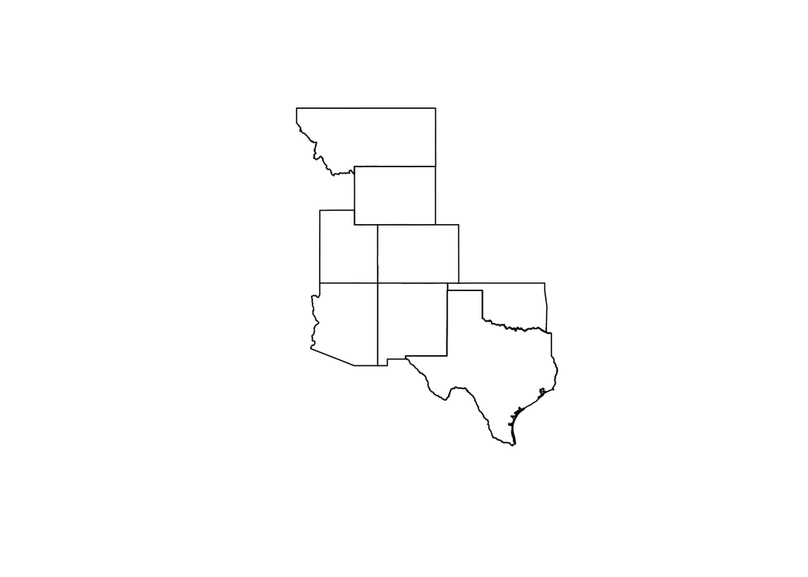

```r
plot(intermountain_zipMap)
```

```r
library(RColorBrewer)
library(classInt)
numberOfClasses = 3
colorForScale='YlGnBu'
colors = brewer.pal(numberOfClasses, colorForScale)
intervals <- classIntervals(varToPlot, numberOfClasses,
                            style = "quantile",
                            dataPrecision=2)
colorPallette <- findColours(intervals, colors)
```

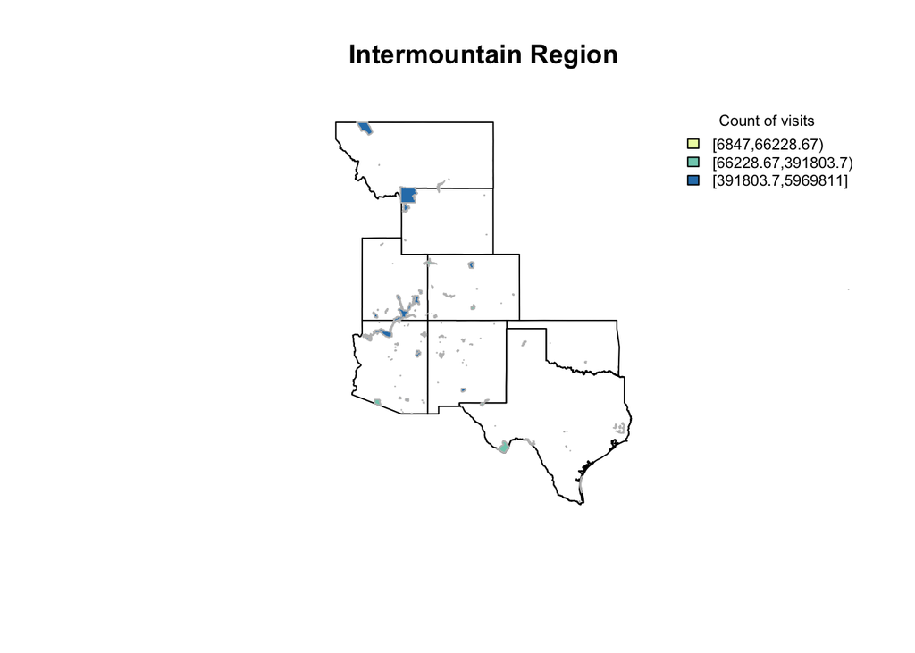

```r
legendText="Count of visits"
shrinkLegend=0.7
title="Intermountain Region"

plot(intermountain_zipMap,col='white',main=title)
plot(IntermounMap, col = colorPallette,border='grey',add=TRUE)
legend('topright', legend = names(attr(colorPallette, "table")),
       fill = attr(colorPallette, "palette"), cex = shrinkLegend,
       bty = "n",
       title=legendText)
```

3.1. Creating a Map Part 3: Define the input for the Midwest Region Map:

```r
varToPlot=midWMap$Recreation_Visits
```

3.1. Creating a Map Part 3.1: Get colors and intervals for the Midwest Region Map:

```r
compressedMap_midwest="https://github.com/alexaschreier/PROJECT/raw/master/nps_boundary/midwest.zip"
```

```r
temp=tempfile()
download.file(compressedMap_midwest, temp)
unzip(temp)
```

```r
(maps=list.files(pattern = 'shp'))
```

```
## [1] "alaska.shp"        "alaskaframe.shp"   "capital.shp"
## [4] "intermountain.shp" "midwest.shp"       "northeast.shp"
## [7] "pacificwest.shp"   "southeast.shp"
```

```r
midwest_zipMap <- rgdal::readOGR("nps_boundary/midwest.shp",stringsAsFactors=F)
names(midwest_zipMap)
```

```
## [1] "STATEFP"  "STATENS"  "AFFGEOID" "GEOID"    "STUSPS"   "NAME"
## [7] "LSAD"     "ALAND"    "AWATER"
```

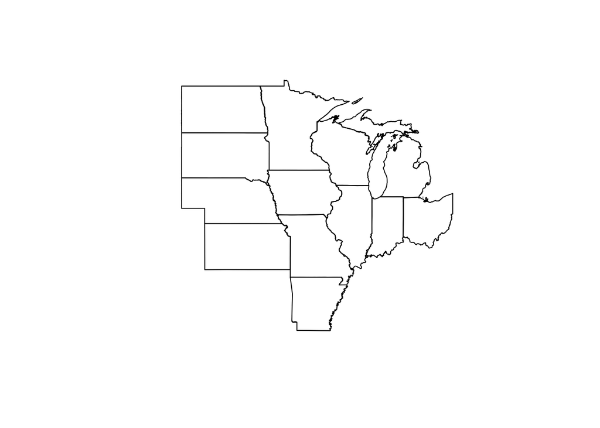

```r
plot(midwest_zipMap)
```

```r
library(RColorBrewer)
library(classInt)
numberOfClasses = 3
colorForScale='YlGnBu'
colors = brewer.pal(numberOfClasses, colorForScale)
intervals <- classIntervals(varToPlot, numberOfClasses,
                            style = "quantile",
                            dataPrecision=2)
colorPallette <- findColours(intervals, colors)
```

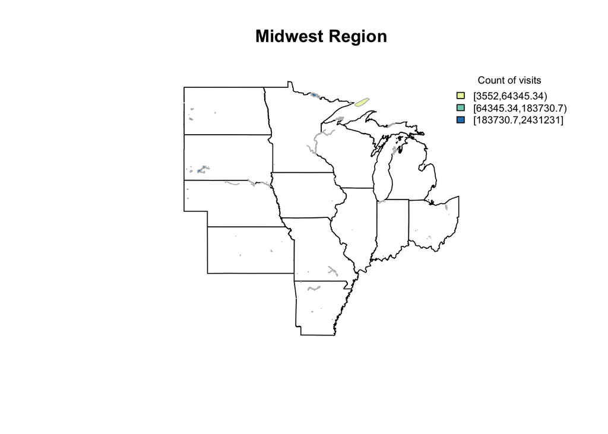

```r
legendText="Count of visits"
shrinkLegend=0.7
title="Midwest Region"

plot(midwest_zipMap,col='white',main=title)
plot(midWMap, col = colorPallette,border='grey',add=TRUE)
legend('topright', legend = names(attr(colorPallette, "table")),
       fill = attr(colorPallette, "palette"), cex = shrinkLegend,
       bty = "n",
       title=legendText)
```

3.1. Creating a Map Part 4: Define the input for the National Capital Region Map:

```r
varToPlot=natioCapMap$Recreation_Visits
```

3.1. Creating a Map Part 4.1: Get colors and intervals for the National Capital Region Map:

```r
compressedMap_nationalcap="https://github.com/alexaschreier/PROJECT/raw/master/nps_boundary/capital.zip"
```

```r
temp=tempfile()
download.file(compressedMap_nationalcap, temp)
unzip(temp)
```

```r
(maps=list.files(pattern = 'shp'))
```

```
## [1] "alaska.shp"        "alaskaframe.shp"   "capital.shp"
## [4] "intermountain.shp" "midwest.shp"       "northeast.shp"
## [7] "pacificwest.shp"   "southeast.shp"
```

```r
nationalcap_zipMap <- rgdal::readOGR("nps_boundary/capital.shp",stringsAsFactors=F)
names(nationalcap_zipMap)
```

```
## [1] "STATEFP"  "STATENS"  "AFFGEOID" "GEOID"    "STUSPS"   "NAME"
## [7] "LSAD"     "ALAND"    "AWATER"
```

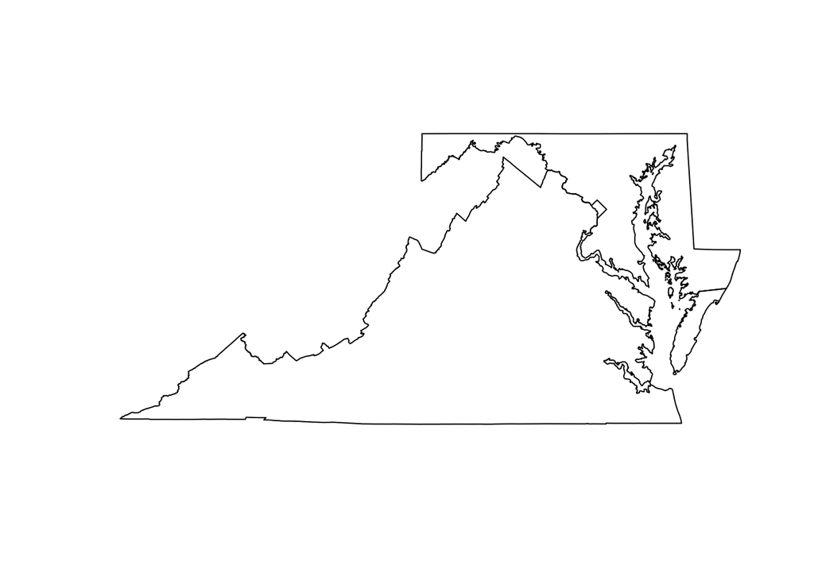

```r
plot(nationalcap_zipMap)
```

```r
library(RColorBrewer)
library(classInt)
numberOfClasses = 3
colorForScale='YlGnBu'
colors = brewer.pal(numberOfClasses, colorForScale)
intervals <- classIntervals(varToPlot, numberOfClasses,
                            style = "quantile",
                            dataPrecision=2)
colorPallette <- findColours(intervals, colors)
```

[figure not shown]

```r
legendText="Count of visits"
shrinkLegend=0.7
title="National Capital Region"

plot(nationalcap_zipMap,col='white',main=title)
plot(natioCapMap, col = colorPallette,border='grey',add=TRUE)
legend('topleft', legend = names(attr(colorPallette, "table")),
       fill = attr(colorPallette, "palette"), cex = shrinkLegend,
       bty = "n",
       title=legendText)
```

3.1. Creating a Map Part 5: Define the input for the Northeast Region Map:

```r
varToPlot=northEMap$Recreation_Visits
```

3.1. Creating a Map Part 5.1: Get colors and intervals for the Northeast Region Map:

```r
compressedMap_northeast="https://github.com/alexaschreier/PROJECT/raw/master/nps_boundary/northeast.zip"
```

```r
temp=tempfile()
download.file(compressedMap_northeast, temp)
unzip(temp)
```

```r
(maps=list.files(pattern = 'shp'))
```

```
## [1] "alaska.shp"        "alaskaframe.shp"   "capital.shp"
## [4] "intermountain.shp" "midwest.shp"       "northeast.shp"
## [7] "pacificwest.shp"   "southeast.shp"
```

```r
northeast_zipMap <- rgdal::readOGR("nps_boundary/northeast.shp",stringsAsFactors=F)
names(northeast_zipMap)
```

```
## [1] "STATEFP"  "STATENS"  "AFFGEOID" "GEOID"    "STUSPS"   "NAME"
## [7] "LSAD"     "ALAND"    "AWATER"
```

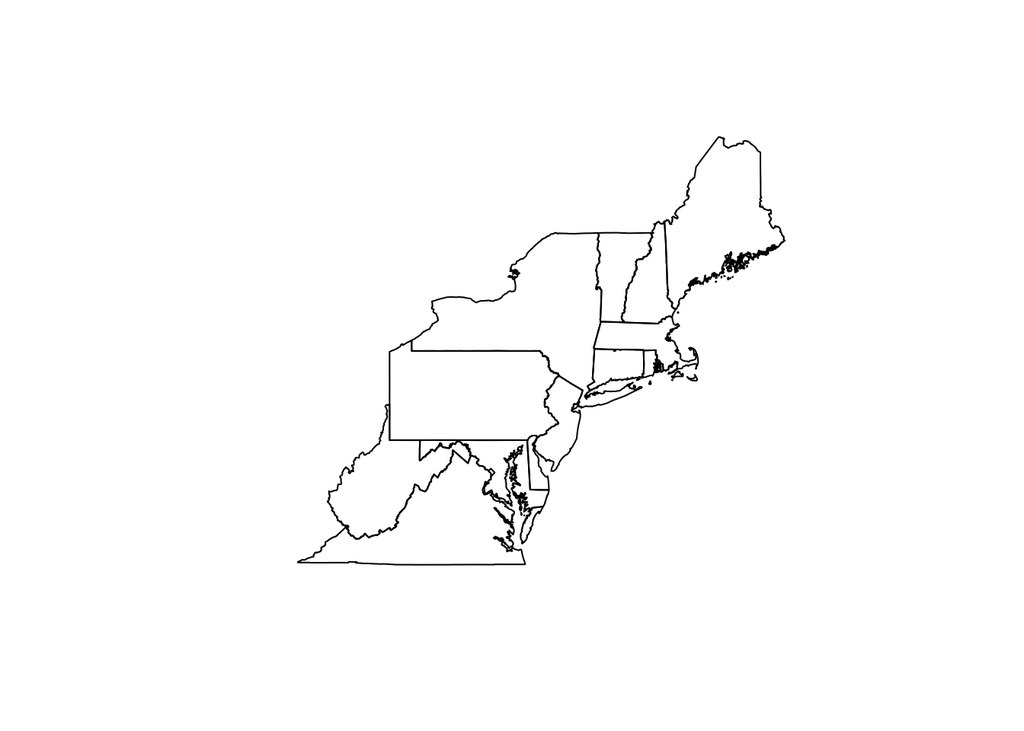

```r
plot(northeast_zipMap)
```

```r
library(RColorBrewer)
library(classInt)
numberOfClasses = 3
colorForScale='YlGnBu'
colors = brewer.pal(numberOfClasses, colorForScale)
intervals <- classIntervals(varToPlot, numberOfClasses,
                            style = "quantile",
                            dataPrecision=2)
colorPallette <- findColours(intervals, colors)
```

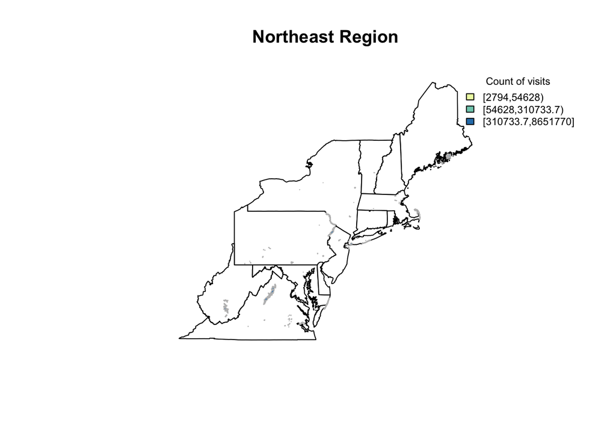

```r
legendText="Count of visits"
shrinkLegend=0.7
title="Northeast Region"

plot(northeast_zipMap,col='white',main=title)
plot(northEMap, col = colorPallette,border='grey',add=TRUE)
legend('topright', legend = names(attr(colorPallette, "table")),
       fill = attr(colorPallette, "palette"), cex = shrinkLegend,
       bty = "n",
       title=legendText)
```

3.1. Creating a Map Part 6: Define the input for the Pacific West Region Map:

```r
varToPlot=pacWestMap$Recreation_Visits
```

3.1. Creating a Map Part 6.1: Get colors and intervals for the Pacific West Region Map:

```r
compressedMap_pacificwest="https://github.com/alexaschreier/PROJECT/raw/master/nps_boundary/pacificwest.zip"
```

```r
temp=tempfile()
download.file(compressedMap_pacificwest, temp)
unzip(temp)
```

```r
(maps=list.files(pattern = 'shp'))
```

```
## [1] "alaska.shp"        "alaskaframe.shp"   "capital.shp"
## [4] "intermountain.shp" "midwest.shp"       "northeast.shp"
## [7] "pacificwest.shp"   "southeast.shp"
```

```r
pacificwest_zipMap <- rgdal::readOGR("nps_boundary/pacificwest.shp",stringsAsFactors=F)
names(pacificwest_zipMap)
```

```
## [1] "STATEFP"  "STATENS"  "AFFGEOID" "GEOID"    "STUSPS"   "NAME"
## [7] "LSAD"     "ALAND"    "AWATER"
```

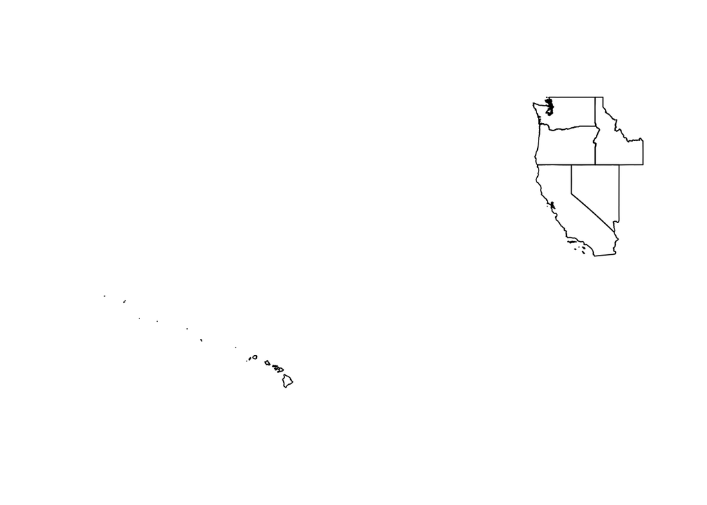

```r
plot(pacificwest_zipMap)
```

```r
library(RColorBrewer)
library(classInt)
numberOfClasses = 3
colorForScale='YlGnBu'
colors = brewer.pal(numberOfClasses, colorForScale)
intervals <- classIntervals(varToPlot, numberOfClasses,
                            style = "quantile",
                            dataPrecision=2)
colorPallette <- findColours(intervals, colors)
```

```r
#legendText="Count of visits"
#shrinkLegend=0.7
#title="Pacific West Region"

#plot(pacificwest_zipMap,col='white',main=title)
#plot(pacWestMap, col = colorPallette,border='grey',add=TRUE)
#legend('topleft', legend = names(attr(colorPallette, "table")),
       #fill = attr(colorPallette, "palette"), cex = shrinkLegend,
       #bty = "n",
       #title=legendText)
```

3.1. Creating a Map Part 7: Define the input for the South East Region Map:

```r
varToPlot=southEMap$Recreation_Visits
```

3.1. Creating a Map Part 7.1: Get colors and intervals for the South East Region Map:

```r
compressedMap_southeast="https://github.com/alexaschreier/PROJECT/raw/master/nps_boundary/southeast.zip"
```

```r
temp=tempfile()
download.file(compressedMap_southeast, temp)
unzip(temp)
```

```r
(maps=list.files(pattern = 'shp'))
```

```
## [1] "alaska.shp"        "alaskaframe.shp"   "capital.shp"
## [4] "intermountain.shp" "midwest.shp"       "northeast.shp"
## [7] "pacificwest.shp"   "southeast.shp"
```

```r
southeast_zipMap <- rgdal::readOGR("nps_boundary/southeast.shp",stringsAsFactors=F)
names(southeast_zipMap)
```

```
## [1] "STATEFP"  "STATENS"  "AFFGEOID" "GEOID"    "STUSPS"   "NAME"
## [7] "LSAD"     "ALAND"    "AWATER"
```

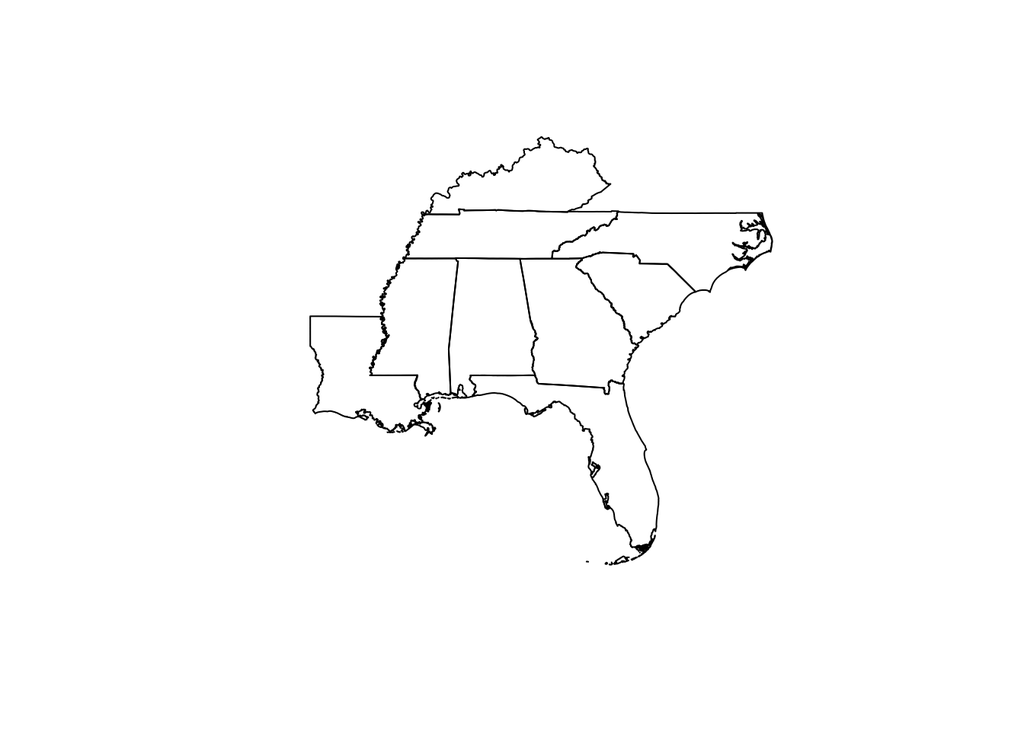

```r
plot(southeast_zipMap)
```

```r
library(RColorBrewer)
library(classInt)
numberOfClasses = 3
colorForScale='YlGnBu'
colors = brewer.pal(numberOfClasses, colorForScale)
intervals <- classIntervals(varToPlot, numberOfClasses,
                            style = "quantile",
                            dataPrecision=2)
colorPallette <- findColours(intervals, colors)
```

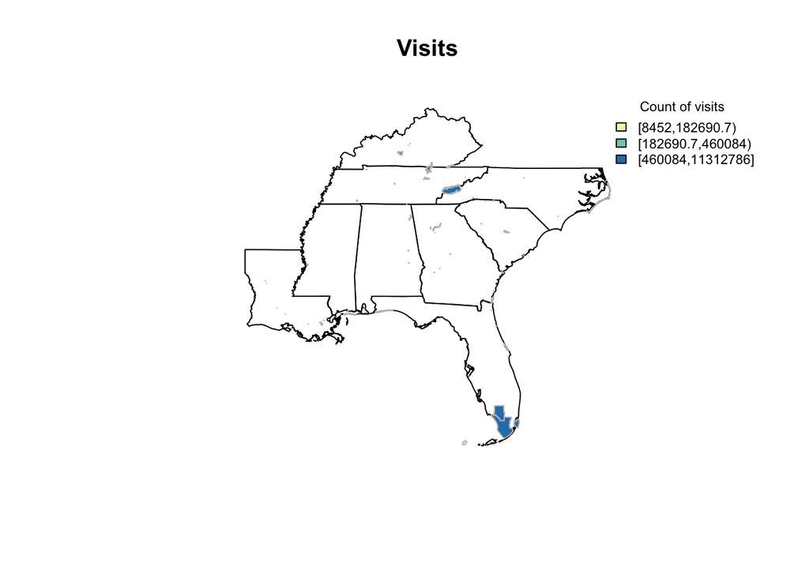

```r
legendText="Count of visits"
shrinkLegend=0.7
title="Visits"

plot(southeast_zipMap,col='white',main=title)
plot(southEMap, col = colorPallette,border='grey',add=TRUE)
legend('topright', legend = names(attr(colorPallette, "table")),
       fill = attr(colorPallette, "palette"), cex = shrinkLegend,
       bty = "n",
       title=legendText)
```